# Peer-graded Assignment: Statistical Inference Course Project

# Part 2: Basic Inferential Data Analysis

In this second portion of the project, we’re going to analyze the ToothGrowth data in the R datasets package.

### Load the ToothGrowth data and perform some basic exploratory data analyses

As per dicumentation `?ToothGrowth`: “The response is the length of odontoblasts (cells responsible for tooth growth) in 60 guinea pigs. Each animal received one of three dose levels of vitamin C (0.5, 1, and 2 mg/day) by one of two delivery methods, (orange juice or ascorbic acid).”

```r
data("ToothGrowth")
```

### Provide a basic summary of the data.

We can see it’s data frame with 60 observations on 3 variables.

```r
head(ToothGrowth)
```

```
##    len supp dose
## 1  4.2   VC  0.5
## 2 11.5   VC  0.5
## 3  7.3   VC  0.5
## 4  5.8   VC  0.5
## 5  6.4   VC  0.5
## 6 10.0   VC  0.5
```

```r
str(ToothGrowth)
```

```
## 'data.frame':    60 obs. of  3 variables:
##  $ len : num  4.2 11.5 7.3 5.8 6.4 10 11.2 11.2 5.2 7 ...
##  $ supp: Factor w/ 2 levels "OJ","VC": 2 2 2 2 2 2 2 2 2 2 ...
##  $ dose: num  0.5 0.5 0.5 0.5 0.5 0.5 0.5 0.5 0.5 0.5 ...
```

```r
summary(ToothGrowth)
```

```
##       len        supp         dose
##  Min.   : 4.20   OJ:30   Min.   :0.500
##  1st Qu.:13.07   VC:30   1st Qu.:0.500
##  Median :19.25           Median :1.000
##  Mean   :18.81           Mean   :1.167
##  3rd Qu.:25.27           3rd Qu.:2.000
##  Max.   :33.90           Max.   :2.000
```

```r
sd(ToothGrowth$len) #check the overall variability of response variable
```

```
## [1] 7.649315
```

We can also perform some **exploratory analysis in order to formulate hypothesis** later. Using a **boxplot** we are able to relate tooth length to both supplement type and dose to see which which inputs (or combination of inputs) have more impact on tooth growth.

Boxplots allow us to visualize distributions, hence understanding mean and variance (the box contains the middle 50% of observations and the horizontal line is the median; note we also plotted the mean by adding a black point in the box; the red points located at the extremes are outliers).

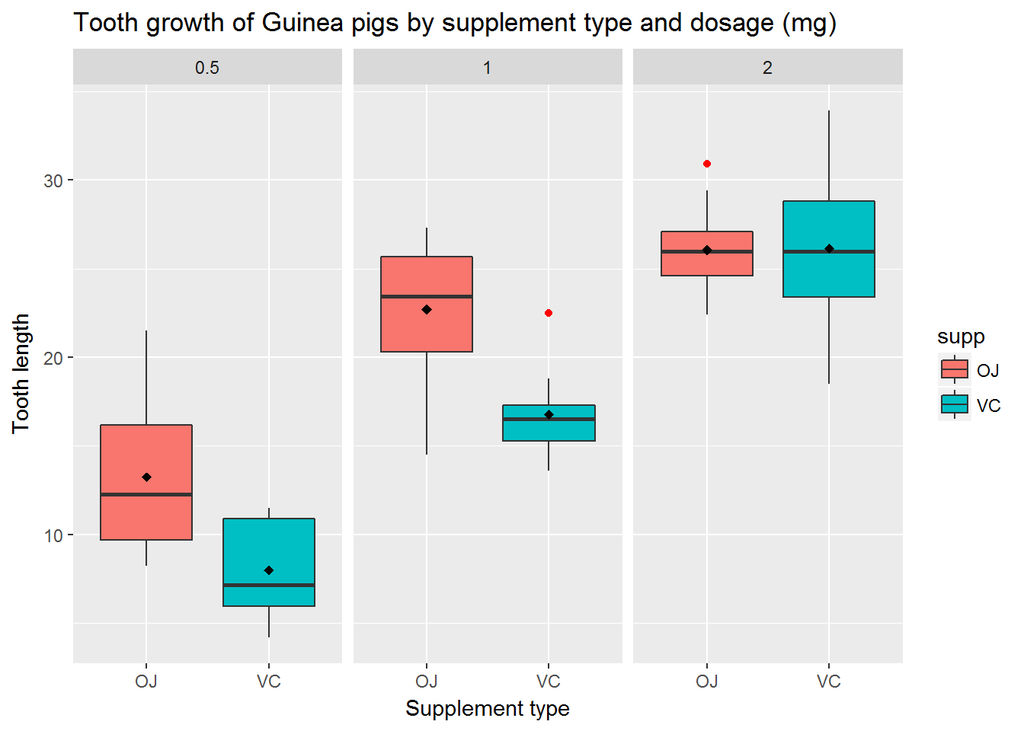

```r
library(ggplot2)
b<- ggplot(aes(x = supp, y = len), data = ToothGrowth, main="Tooth growth of guinea pigs by supplement type and dosage (mg)",xlab="Supplement type", ylab="Tooth length")

b+geom_boxplot(aes(fill =supp),outlier.colour = "red") +
  facet_wrap(~ dose)+
  stat_summary(fun.y=mean, geom="point", shape=18, size=2) +
  ggtitle("Tooth growth of Guinea pigs by supplement type and dosage (mg)") +
  labs(x="Supplement type", y="Tooth length")
```

It looks as, generally there is a positive linear relationship between dosage and tooth growth: the more the dosage and the more teeths grow, using each of the two supplement types. The increase looks particular evident going from 0.5mg to 1mg dosage.

What is not so clear is which supplement type works best. It looks like the OJ type is better for low dosages but then when the dosage increases to 2mg, OJ and VC distributions overlaps.

Confidence intervals and hypothesis testing can help to understand whether the difference between tooth length means of different groups (dosage and supplements) is statistical significant.

### Use confidence intervals and/or hypothesis tests to compare tooth growth by supp and dose.

(Only ##use the techniques from class, even if there’s other approaches worth considering. For instance ANOVA could be a good approach in this case).

### Lets first test relationship between dosage and tooth growth

Since there are 3 different levels of dosage (0.5,1,2) in the data, we will start performing 2 separate **t-tests**, comparing difference in means between:

- 0.5mg and 1mg dosage
- 1mg and 2mg dosage

**Test 0.5mg vs 1mg dosage**

```r
library(dplyr)
test1<-filter(ToothGrowth, dose %in% c(0.5,1))
#in the t.test function we can set the paired parameter equal FALSe because pigs that received 0.5 dosage were a separate set of pigs than those that received 1mg dosage. The same assumption will be made in subsequent tests.
t.test(len~dose,paired=FALSE,var.equal=TRUE,data=test1)
```

```
##
##  Two Sample t-test
##
## data:  len by dose
## t = -6.4766, df = 38, p-value = 1.266e-07
## alternative hypothesis: true difference in means is not equal to 0
## 95 percent confidence interval:
##  -11.983748  -6.276252
## sample estimates:
## mean in group 0.5   mean in group 1
##            10.605            19.735
```

The test looks statistically significant given an alpha level of 5%. The p-values is much lower than 0.05. So, it should be very unlikely to get this t-statistic if the null hypothesis (there is not difference in length means between the two dosage levels) was actually true. In other words it looks **there is a statistically significant difference** between tooth lenght means of pigs who were treated with a dosage level of 1mg instead of 0.5mg.

```r
test2<-filter(ToothGrowth, dose %in% c(1,2))
t.test(len~dose,paired=FALSE,var.equal=TRUE,data=test2)
```

```
##
##  Two Sample t-test
##
## data:  len by dose
## t = -4.9005, df = 38, p-value = 1.811e-05
## alternative hypothesis: true difference in means is not equal to 0
## 95 percent confidence interval:
##  -8.994387 -3.735613
## sample estimates:
## mean in group 1 mean in group 2
##          19.735          26.100
```

Again, p-value is much lower than our alpha level of 0.05, so it seems it’s unlikely that the higher tooth growth obtained with a dosage of 2mg would have happened by chance under the null hypothesis. In conclusion, **we can reject the null hypothesis**.

Given our results as well as looking at previous boxplots, we reckon it’s not necessary to test difference in means between the 0.5 and 2mg groups.

### Finally test relationship between supplement type and tooth growth

We wil perform only one test since there are two supplemt types available in the dataset.

**Test OJ vs VC supp type**

```r
t.test(len~supp,paired=FALSE,var.equal=TRUE,data=ToothGrowth)
```

```
##
##  Two Sample t-test
##
## data:  len by supp
## t = 1.9153, df = 58, p-value = 0.06039
## alternative hypothesis: true difference in means is not equal to 0
## 95 percent confidence interval:
##  -0.1670064  7.5670064
## sample estimates:
## mean in group OJ mean in group VC
##         20.66333         16.96333
```

In this case the p-value is higher than our alpha threeshold of 0.05. Even if there might be some relationship between one specific supplement and the response variable, it is not statistically significant. Hence **we can’t reject the null Hypothesis** stating there is no difference between OJ tooth growth mean of VC tooth growth mean.

To undestand further the relationship between all variable, it might make sense to **understand the effect of the interaction between input variables** on the response variable. In particular, as showed in above the boxplot, it would be interesting to see if the OJ supplement is more effective for low dosages (reject null hypothesis) while there is no evidence of difference in means for higher dosages like 2mg. However we won’t perform these analysis.